# ANÁLISE DE DADOS

LUAN FIORENTIN

Atualizado em 24 / 02 / 2021 as 20:30 horas

# 1 **OBJETIVOS**

O objetivo da análise é verificar se há diferença significativa de `Temperature`, `Relative umidity`, `Air velocity`, `NH3` e `Illuminance` entre os níveis de `Environmental indicators` (Natural light - `NL` e Artificial light - `AL`) e `Week` (`1`, `2`, `3`, `4`, `5` e `6`).

# 2 **MATERIAIS E MÉTODOS**

## 2.1 Descrição do experimento

Os dados em análise se referem a informações que expressam as condições de ambiente de um galpão com animais. O estudo trata-se de um Experimento Fatorial com dois fatores. O fator `Environmental indicators` possui os níveis Artificial light - `AL` e Natural light - `NL`, enquanto `Week` possui os níveis `1`, `2`, `3`, `4`, `5` e `6`. As cinco variáveis respostas foram denominadas de `Temperature`, `Relative umidity`, `Air velocity`, `NH3` e `Illuminance`. As variáveis analisadas foram quantificadas em um único galpão apenas, e as medições foram realizadas diariamente as 10 horas na idade de 2 a 36 dias de vida dos animais, mas as 15 horas na idade de 1 a 36 dias. Devido a falta de repetições genuínas, optou-se por considerar as observações tomadas na mesma semana como pseudo-repetições. Assim, 13 observações constaram na primeira semana, 14 na segunda até quinta semana, mas apenas 2 na sexta semana.

## 2.2 Análise estatística

A partir dos dados, foi possível ajustar um modelo de regressão fatorial para estimar os efeitos dos dois fatores para cada variável resposta. Todas as análises foram realizadas com nível de significância $\alpha = 0.05$, por meio do programa estatístico `R` (R CORE TEAM (2009)). Os modelos fatoriais foram ajustados com pacotes básicos do programa. Os contrastes de médias foram estimados no pacote `emmeans` (LENTH (2020)) e o teste de Tukey foi utilizado para comparação múltipla de médias. A qualidade de ajuste dos modelos foi avaliada por meio de gráficos *half-normal plots*, disponíveis no pacote `hnp` (MORAL et al. (2017)). Os gráficos foram construídos por meio do pacote `ggplot2` (WICKHAM (2016)).

# 3 **RESULTADOS**

Os tópicos a seguir apresentam os resultados da análise exploratória de dados e o teste de comparação de médias, considerando nível de significância $\alpha = 0.05$.

## 3.1 Análise exploratória de dados

A tabela a seguir mostra as medidas de resumo de número de observações (n), mínimo (Minimum), mediana (Median), média (Mean), máximo (Maximum) e desvio padrão (Standard error) das cinco variáveis respostas (Variable), para cada nível dos fatores de `Environmental indicators` e `Week`.

Medidas de resumo das variáveis respostas por nível dos fatores `Environmental indicators` e `Week`.

| Variable | Environmental indicators | Week | n | Minimum | Median | Mean | Maximum | Standard error |
| --- | --- | --- | --- | --- | --- | --- | --- | --- |
| Temperature | AL | 1 | 13 | 26.6 | 28.90 | 28.63 | 30.9 | 1.15 |
| Temperature | AL | 2 | 14 | 23.7 | 25.15 | 25.58 | 30.1 | 1.64 |
| Temperature | AL | 3 | 14 | 22.8 | 24.25 | 24.24 | 25.4 | 0.74 |
| Temperature | AL | 4 | 14 | 22.5 | 23.25 | 23.28 | 23.8 | 0.40 |
| Temperature | AL | 5 | 14 | 21.3 | 22.35 | 22.40 | 23.6 | 0.82 |
| Temperature | AL | 6 | 2 | 20.7 | 21.05 | 21.05 | 21.4 | 0.49 |
| Temperature | NL | 1 | 13 | 27.3 | 29.00 | 28.77 | 30.4 | 1.11 |
| Temperature | NL | 2 | 14 | 24.0 | 25.45 | 25.93 | 30.3 | 1.63 |
| Temperature | NL | 3 | 14 | 23.4 | 24.50 | 24.60 | 26.0 | 0.85 |
| Temperature | NL | 4 | 14 | 22.6 | 23.55 | 23.60 | 24.3 | 0.53 |
| Temperature | NL | 5 | 14 | 21.4 | 22.45 | 22.57 | 23.9 | 0.90 |
| Temperature | NL | 6 | 2 | 20.8 | 21.25 | 21.25 | 21.7 | 0.64 |
| Relative humidity | AL | 1 | 13 | 64.0 | 65.30 | 67.35 | 73.1 | 3.43 |
| Relative humidity | AL | 2 | 14 | 64.8 | 71.50 | 71.16 | 75.0 | 2.49 |
| Relative humidity | AL | 3 | 14 | 70.0 | 73.50 | 73.07 | 76.0 | 1.94 |
| Relative humidity | AL | 4 | 14 | 71.0 | 73.00 | 73.43 | 76.0 | 1.65 |
| Relative humidity | AL | 5 | 14 | 64.0 | 74.00 | 74.00 | 80.0 | 5.36 |
| Relative humidity | AL | 6 | 2 | 75.0 | 75.00 | 75.00 | 75.0 | 0.00 |
| Relative humidity | NL | 1 | 13 | 64.2 | 65.40 | 67.49 | 73.5 | 3.45 |
| Relative humidity | NL | 2 | 14 | 63.8 | 71.00 | 70.81 | 76.0 | 2.95 |
| Relative humidity | NL | 3 | 14 | 68.0 | 73.00 | 72.57 | 75.0 | 2.14 |
| Relative humidity | NL | 4 | 14 | 70.0 | 73.00 | 73.29 | 76.0 | 1.77 |
| Relative humidity | NL | 5 | 14 | 65.0 | 74.00 | 74.07 | 80.0 | 5.12 |
| Relative humidity | NL | 6 | 2 | 74.0 | 74.50 | 74.50 | 75.0 | 0.71 |
| Air velocity | AL | 1 | 13 | 0.0 | 0.00 | 0.47 | 1.3 | 0.62 |
| Air velocity | AL | 2 | 14 | 0.0 | 1.05 | 0.72 | 1.2 | 0.56 |
| Air velocity | AL | 3 | 14 | 0.0 | 0.00 | 0.51 | 1.3 | 0.61 |
| Air velocity | AL | 4 | 14 | 0.0 | 1.20 | 0.91 | 1.3 | 0.50 |
| Air velocity | AL | 5 | 14 | 0.0 | 1.20 | 1.01 | 1.3 | 0.44 |
| Air velocity | AL | 6 | 2 | 1.2 | 1.20 | 1.20 | 1.2 | 0.00 |
| Air velocity | NL | 1 | 13 | 0.0 | 0.00 | 0.47 | 1.3 | 0.62 |
| Air velocity | NL | 2 | 14 | 0.0 | 1.00 | 0.76 | 1.2 | 0.51 |
| Air velocity | NL | 3 | 14 | 0.0 | 0.00 | 0.51 | 1.3 | 0.62 |
| Air velocity | NL | 4 | 14 | 0.0 | 1.10 | 0.86 | 1.2 | 0.47 |
| Air velocity | NL | 5 | 14 | 0.0 | 1.20 | 1.01 | 1.3 | 0.43 |
| Air velocity | NL | 6 | 2 | 1.1 | 1.10 | 1.10 | 1.1 | 0.00 |
| NH3 | AL | 1 | 13 | 0.0 | 0.00 | 0.00 | 0.0 | 0.00 |
| NH3 | AL | 2 | 14 | 0.0 | 0.50 | 0.50 | 1.0 | 0.52 |
| NH3 | AL | 3 | 14 | 0.0 | 2.00 | 1.64 | 3.0 | 0.93 |
| NH3 | AL | 4 | 14 | 1.0 | 2.00 | 2.14 | 3.0 | 0.66 |
| NH3 | AL | 5 | 14 | 2.0 | 3.00 | 3.21 | 4.0 | 0.58 |
| NH3 | AL | 6 | 2 | 2.0 | 3.00 | 3.00 | 4.0 | 1.41 |
| NH3 | NL | 1 | 13 | 0.0 | 0.00 | 0.00 | 0.0 | 0.00 |
| NH3 | NL | 2 | 14 | 0.0 | 1.00 | 0.64 | 1.0 | 0.50 |
| NH3 | NL | 3 | 14 | 0.0 | 2.00 | 1.64 | 3.0 | 1.01 |
| NH3 | NL | 4 | 14 | 1.0 | 2.00 | 2.21 | 4.0 | 0.89 |
| NH3 | NL | 5 | 14 | 2.0 | 3.00 | 3.43 | 5.0 | 0.76 |
| NH3 | NL | 6 | 2 | 3.0 | 4.00 | 4.00 | 5.0 | 1.41 |
| Illuminance | AL | 1 | 13 | 41.0 | 43.00 | 42.77 | 44.0 | 0.93 |
| Illuminance | AL | 2 | 14 | 40.0 | 41.50 | 41.50 | 43.0 | 1.09 |
| Illuminance | AL | 3 | 14 | 22.0 | 41.50 | 34.00 | 44.0 | 10.38 |
| Illuminance | AL | 4 | 14 | 22.0 | 22.50 | 22.64 | 24.0 | 0.74 |
| Illuminance | AL | 5 | 14 | 22.0 | 23.00 | 23.00 | 24.0 | 0.78 |
| Illuminance | AL | 6 | 2 | 22.0 | 23.00 | 23.00 | 24.0 | 1.41 |
| Illuminance | NL | 1 | 13 | 338.0 | 466.00 | 459.23 | 540.0 | 63.40 |
| Illuminance | NL | 2 | 14 | 390.0 | 500.50 | 503.71 | 624.0 | 74.27 |
| Illuminance | NL | 3 | 14 | 280.0 | 511.00 | 515.14 | 701.0 | 127.69 |
| Illuminance | NL | 4 | 14 | 315.0 | 592.50 | 598.93 | 900.0 | 161.23 |
| Illuminance | NL | 5 | 14 | 470.0 | 632.50 | 628.79 | 750.0 | 93.12 |
| Illuminance | NL | 6 | 2 | 490.0 | 655.00 | 655.00 | 820.0 | 233.35 |

## 3.2 Teste de comparação de médias

Um modelo de regressão fatorial foi ajustado para cada resposta com a finalidade de verificar se há efeito de `Environmental indicators` e `Week`, a nível de significância $\alpha = 0.05$.

O efeito de interação entre os fatores (`Environmental indicators` e `Week`) é significativo para a variável `Illuminance`, como pode ser observado na Figura a seguir. É possível notar que não há diferença nos valores de médias de `Illuminance` entre os níveis do fator, enquanto todas as médias foram distintas quando compara-se o efeito dos níveis de `Week` entre os níveis de `Environmental indicators`.

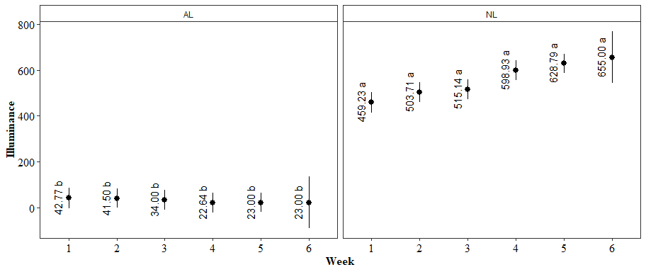

Média estimada e intervalo de confiança de cada nível dos fatores `Environmental indicators` e `Week`. Médias seguidas por letras iguais não diferem estatisticamente entre si pelo teste de Tukey a 5% de significância.

O efeito de interação entre `Environmental indicators` e `Week` é não significativo para as variáveis `Temperature`, `Relative humidity`, `Air velocity` e `NH3`. Também é observado efeito não significativo de `Environmental indicators` em todas as quatro variáveis. No entanto, optou-se por manter no modelo com a finalidade de obter os valores de médias por nível de fator. Por outro lado, há efeito significativo de `Week`, com uma clara tendência de diminuir os valores de `Temperature` em função do tempo. As demais variáveis apresentam um claro padrão de aumentar seus valores, mas com uma aparente estabilização na média para os níveis `Week = 5` e `Week = 6`. O intervalo de confiança foi maior para o efeito da sexta semana devido ao menor número de observações disponíveis (apenas 2 observações).

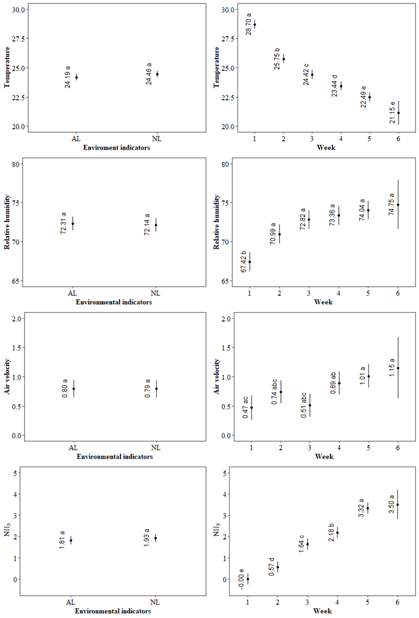

Média estimada e intervalo de confiança de cada nível dos fatores `Environmental indicators` e `Week`. Médias seguidas por letras iguais não diferem estatisticamente entre si pelo teste de Tukey a 5% de significância.

# 4 **CONTATO**

Conheça a [$\color{green}{\textbf{FOR DATA}}$](https://instagram.com/fordata4d?igshid=1xn4ub0hs4g7w) no instagram! Se gostar do conteúdo, Curta, Comente e Compatilhe com amigos!  
:)

[figure not shown]

# **REFERÊNCIAS**

LENTH, R. **Emmeans: Estimated marginal means, aka least-squares means**. 2020.

MORAL, R. A.; HINDE, J.; DEMÉTRIO, C. G. B. Half-normal plots and overdispersed models in R: The hnp package. **Journal of Statistical Software**, v. 81, n. 10, p. 1–23, 2017.

R CORE TEAM. **R: A language and environment for statistical computing**. Vienna, Austria: R Foundation for Statistical Computing, 2009.

WICKHAM, H. **Ggplot2: Elegant graphics for data analysis**. Springer-Verlag New York, 2016.